# Tugas 2 Praktikum

# Import Library

```r
library(lmtest)
```

```r
library(orcutt)
library(ggplot2)
library (dplyr)
library(readxl)
library(HoRM)
```

# No 1

## A. Read Dataset

```r
df1 <- read_excel("C:\\Users\\a c e r\\Music\\SEMESTER 5\\KULIAH\\MPDW\\PRAKTIKUM\\PERTEMUAN 3\\Data1.xlsx")
df1
```

```
## # A tibble: 20 × 3
##    Period `Market share` Price
##     <dbl>          <dbl> <dbl>
##  1      1           3.63  0.97
##  2      2           4.2   0.95
##  3      3           3.33  0.99
##  4      4           4.54  0.91
##  5      5           2.89  0.98
##  6      6           4.87  0.9
##  7      7           4.9   0.89
##  8      8           5.29  0.86
##  9      9           6.18  0.85
## 10     10           7.2   0.82
## 11     11           7.25  0.79
## 12     12           6.09  0.83
## 13     13           6.8   0.81
## 14     14           8.65  0.77
## 15     15           8.43  0.76
## 16     16           8.29  0.8
## 17     17           7.18  0.83
## 18     18           7.9   0.79
## 19     19           8.45  0.76
## 20     20           8.23  0.78
```

## B. Pre-processing

Pada tahap pra-pemrosesan data, kolom Period dihapus karena tidak digunakan sebagai peubah bebas, sedangkan peubah Market share diubah namany menjadi Y (peubah respon) dan Price menjadi X (peubah bebas).

```r
data1 <- df1 %>%
  select(-Period) %>%
  rename(Y = `Market share`,
         X = Price)
```

## C. Pemodelan Awal

Model regresi linear sederhana dibentuk menggunakan metode kuadrat terkecil OLS untuk melihat hubungan awal antara harga (X) dan pangsa pasar (Y).

```r
model_awal1 <- lm(Y ~ X, data = data1)
summary(model_awal1)
```

```
##
## Call:
## lm(formula = Y ~ X, data = data1)
##
## Residuals:
##      Min       1Q   Median       3Q      Max
## -0.73068 -0.29764 -0.00966  0.30224  0.81193
##
## Coefficients:
##             Estimate Std. Error t value Pr(>|t|)
## (Intercept)   26.910      1.110   24.25 3.39e-15 ***
## X            -24.290      1.298  -18.72 3.02e-13 ***
## ---
## Signif. codes:  0 '***' 0.001 '**' 0.01 '*' 0.05 '.' 0.1 ' ' 1
##
## Residual standard error: 0.4287 on 18 degrees of freedom
## Multiple R-squared:  0.9511, Adjusted R-squared:  0.9484
## F-statistic: 350.3 on 1 and 18 DF,  p-value: 3.019e-13
```

## D. Uji Asumsi Eksploratif

Uji asumsi sisaan dilakukan secara eksploratif melalui analisis grafik kuartet (QQ plot, Fitted vs Residuals, Histogram, dan Order vs Residuals) untuk mendeteksi secara visual adanya pelanggaran kelayakan model OLS.

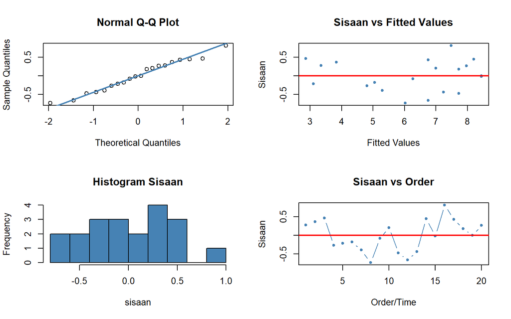

```r
sisaan <- residuals(model_awal1)
fitValue <- predict(model_awal1)
n <- length(sisaan)

par(mfrow = c(2,2))
qqnorm(sisaan)
qqline(sisaan, col = "steelblue", lwd = 2)

plot(fitValue, sisaan, col = "steelblue", pch = 20, xlab = "Fitted Values", ylab = "Sisaan", main = "Sisaan vs Fitted Values")
abline(h = 0, col = "red", lwd = 2)

hist(sisaan, col = "steelblue", main = "Histogram Sisaan")

plot(1:n, sisaan, col = "steelblue", pch = 20, type = "b", xlab = "Order/Time", ylab = "Sisaan", main = "Sisaan vs Order")
abline(h = 0, col = "red", lwd = 2)
```

```r
par(mfrow = c(1,1))
```

## E. Uji Shapiro-Wilk (Normalitas)

Hipotesis:

$H_0$: Sisaan berdistribusi normal

$H_1$: Sisaan tidak berdistribusi normal

Interpretasi:Jika $p\text{-value} > 0.05$, gagal tolak $H_0$. Asumsi normalitas sisaan terpenuhi.

```r
shapiro.test(residuals(model_awal1))
```

```
##
##  Shapiro-Wilk normality test
##
## data:  residuals(model_awal1)
## W = 0.9744, p-value = 0.8437
```

Berdasarkan hasil dari Shapiro-wilk Test, nilai p-value adalah $0,8437$ yang lebih dari $0,05$. Berarti data menyebar normal.

## F. Uji Breusch-Pagan (Homoskedastisitas)

Hipotesis:

$H_0$: Ragam sisaan homogen (homoskedastisitas)

$H_1$: Ragam sisaan tidak homogen (heteroskedastisitas)

Interpretasi:Jika $p\text{-value} > 0.05$, gagal tolak $H_0$. Asumsi kehomogenan ragam sisaan terpenuhi.

```r
bptest(model_awal1)
```

```
##
##  studentized Breusch-Pagan test
##
## data:  model_awal1
## BP = 0.11646, df = 1, p-value = 0.7329
```

Berdasarkan hasil dari Breusch-Pagan Test, didapatkan nilai p-value sebesar $0,7329$ yang lebih besar dari $0,05$. Berarti asumsi kehobogenan ragam sisaan terpenuhi.

## G. Uji Durbin-Watson (Autokorelasi)

Hipotesis:

$H_0$: Tidak ada autokorelasi sisaan ($\rho = 0$)

$H_1$: Ada autokorelasi sisaan ($\rho \neq 0$)

Interpretasi:Jika $p\text{-value} < 0.05$ (atau statistik $DW$ jauh dari nilai 2 / berada pada daerah penolakan $H_0$), maka keputusan adalah Tolak $H_0$. Hal ini membuktikan bahwa terdapat masalah autokorelasi pada model OLS awal, sehingga estimasi parameter menjadi kurang efisien (ragam pembobot OLS tidak lagi minimum) dan memerlukan penanganan.

```r
dwtest(model_awal1)
```

```
##
##  Durbin-Watson test
##
## data:  model_awal1
## DW = 1.1358, p-value = 0.009813
## alternative hypothesis: true autocorrelation is greater than 0
```

Berdasarkan hasil dari Durbin-Watson Test, didapatkan nilai p-value sebesar $0,009813$ yang lebih kecil dari $0,05$. Itu berarti terdapat potensi autokorelasi pada data.

## H. Penanganan Autokorelasi dengan Metode Cochrane-Orcutt

Karena ditemukan indikasi autokorelasi pada model OLS yang ditunjukkan dengan hasil p-value dari Durbin-Watson test yang bernilai kurang dari $0,05$, metode diferensiasi tingkat pertama Cochrane-Orcutt diterapkan secara iteratif untuk mentransformasi data dan memodelkan ulang peubah.

```r
model_orcutt1 <- cochrane.orcutt(model_awal1)
summary(model_orcutt1)
```

```
## Call:
## lm(formula = Y ~ X, data = data1)
##
##             Estimate Std. Error t value  Pr(>|t|)
## (Intercept)  26.7221     1.6329  16.365 7.713e-12 ***
## X           -24.0841     1.9385 -12.424 5.903e-10 ***
## ---
## Signif. codes:  0 '***' 0.001 '**' 0.01 '*' 0.05 '.' 0.1 ' ' 1
##
## Residual standard error: 0.3955 on 17 degrees of freedom
## Multiple R-squared:  0.9008 ,  Adjusted R-squared:  0.895
## F-statistic: 154.4 on 1 and 17 DF,  p-value: < 5.903e-10
##
## Durbin-Watson statistic
## (original):    1.13582 , p-value: 9.813e-03
## (transformed): 1.95804 , p-value: 4.151e-01
```

## I. Penanganan Autokorelasi dengan Metode Hildreth-Lu

Sebagai alternatif penanganan autokorelasi, metode grid search Hildreth-Lu dilakukan dengan menguji nilai $\rho$ dari $-0.99$ hingga $0.99$ guna mencari nilai $\rho$ yang meminimalkan Sum of Squared Errors (SSE).

```r
rho_seq <- seq(-0.99, 0.99, by = 0.01)
sse_values <- numeric(length(rho_seq))

for (i in seq_along(rho_seq)) {
  fit <- try(hildreth.lu(y = data1$Y, x = data1$X, rho = rho_seq[i]), silent = TRUE)
  if (!inherits(fit, "try-error") && !is.null(fit$sse)) {
    sse_values[i] <- fit$sse
  } else {
    sse_values[i] <- Inf
  }
}

best_rho <- rho_seq[which.min(sse_values)]
cat("Rho Optimal Hildreth-Lu:", best_rho, "\n")
```

```
## Rho Optimal Hildreth-Lu: -0.99
```

```r
model_hl1 <- hildreth.lu(y = data1$Y, x = data1$X, rho = best_rho)
```

## J. Cek Autokorelasi ulang

Evaluasi akhir dilakukan dengan menguji kembali autokorelasi sisaan pada model penanganan (Cochrane-Orcutt dan Hildreth-Lu) menggunakan uji Durbin-Watson untuk memastikan bahwa masalah autokorelasi telah teratasi.

```r
dwtest(model_orcutt1)
```

```
##
##  Durbin-Watson test
##
## data:  model_orcutt1
## DW = 1.958, p-value = 0.4151
## alternative hypothesis: true autocorrelation is greater than 0
```

```r
dwtest(model_hl1)
```

```
##
##  Durbin-Watson test
##
## data:  model_hl1
## DW = 0.59859, p-value = 3.13e-05
## alternative hypothesis: true autocorrelation is greater than 0
```

## K. Kesimpulan

Berdasarkan hasil uji Durbin-Watson ulang pada Data 1, metode Cochrane-Orcutt (model_orcutt1) menghasilkan nilai statistik Durbin-Watson ($DW$) sebesar 1,958 dengan p-value 0,4151. Karena nilai p-value lebih besar dari tingkat signifikansi $\alpha = 0,05$, maka keputusan yang diambil adalah gagal tolak $H_0$, yang berarti tidak terdapat masalah autokorelasi positif pada sisaan model Cochrane-Orcutt dan nilai $DW$ yang mendekati 2 mengindikasikan bahwa asumsi kebebasan sisaan telah terpenuhi. Sebaliknya, metode Hildreth-Lu (model_hl1) menghasilkan nilai $DW$ sebesar 0,59859 dengan p-value sebesar $3,13 \times 10^{-5}$. Karena nilai p-value tersebut jauh lebih kecil dari $\alpha = 0,05$, maka keputusan uji adalah tolak $H_0$, yang menunjukkan bahwa sisaan pada model Hildreth-Lu masih terindikasi mengalami masalah autokorelasi positif.

Dengan demikian, dapat disimpulkan bahwa metode Cochrane-Orcutt merupakan metode penanganan autokorelasi yang lebih efektif dan tepat digunakan untuk Data 1 dibandingkan metode Hildreth-Lu.

# No 2

## A. Read Dataset

```r
df2 <- read_excel("C:\\Users\\a c e r\\Music\\SEMESTER 5\\KULIAH\\MPDW\\PRAKTIKUM\\PERTEMUAN 3\\Data2.xlsx")
df2
```

```
## # A tibble: 40 × 3
##     Year Sales Advertising
##    <dbl> <dbl>       <dbl>
##  1  1975  11.7         9.4
##  2  1976  12           9.6
##  3  1977  12.3        10
##  4  1978  12.8        10.4
##  5  1979  13.1        10.8
##  6  1980  13.6        10.9
##  7  1981  13.9        11.7
##  8  1982  14.4        12.2
##  9  1983  14.7        12.5
## 10  1984  15.3        12.9
## # ℹ 30 more rows
```

## B. Pre-processing

Pra-pemrosesan dilakukan dengan mengeliminasi kolom Year, kemudian mengubah nama peubah Sales menjadi Y (peubah respon) dan Advertising menjadi X (peubah bebas).

```r
data2 <- df2 %>%
  select(-Year) %>%
  rename(Y = Sales,
         X = Advertising)
```

## C. Pemodelan Awal

Model regresi OLS awal dibentuk untuk mengestimasi pengaruh pengeluaran iklan (X) terhadap volume penjualan (Y).

```r
model_awal2 <- lm(Y ~ X, data = data2)
summary(model_awal2)
```

```
##
## Call:
## lm(formula = Y ~ X, data = data2)
##
## Residuals:
##      Min       1Q   Median       3Q      Max
## -1.03758 -0.40343  0.08933  0.45674  0.74036
##
## Coefficients:
##             Estimate Std. Error t value Pr(>|t|)
## (Intercept)  5.96513    0.38092   15.66   <2e-16 ***
## X            0.71035    0.02365   30.04   <2e-16 ***
## ---
## Signif. codes:  0 '***' 0.001 '**' 0.01 '*' 0.05 '.' 0.1 ' ' 1
##
## Residual standard error: 0.527 on 38 degrees of freedom
## Multiple R-squared:  0.9596, Adjusted R-squared:  0.9585
## F-statistic: 902.3 on 1 and 38 DF,  p-value: < 2.2e-16
```

## D. Uji Asumsi Eksploratif

Analisis grafik kuartet sisaan dilakukan kembali untuk mendeteksi potensi pelanggaran asumsi kecocokan model, homoskedastisitas, dan kebebasan sisaan secara visual.

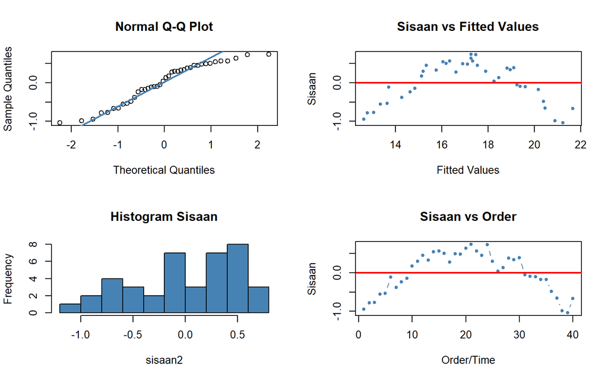

```r
sisaan2 <- residuals(model_awal2)
fitValue2 <- predict(model_awal2)
n2 <- length(sisaan2)

par(mfrow = c(2,2))
qqnorm(sisaan2)
qqline(sisaan2, col = "steelblue", lwd = 2)

plot(fitValue2, sisaan2, col = "steelblue", pch = 20, xlab = "Fitted Values", ylab = "Sisaan", main = "Sisaan vs Fitted Values")
abline(h = 0, col = "red", lwd = 2)

hist(sisaan2, col = "steelblue", main = "Histogram Sisaan")

plot(1:n2, sisaan2, col = "steelblue", pch = 20, type = "b", xlab = "Order/Time", ylab = "Sisaan", main = "Sisaan vs Order")
abline(h = 0, col = "red", lwd = 2)
```

```r
par(mfrow = c(1,1))
```

## E. Uji Shapiro-Wilk (Normalitas)

Hipotesis:

$H_0$: Sisaan berdistribusi normal

$H_1$: Sisaan tidak berdistribusi normal

Interpretasi:Jika $p\text{-value} > 0.05$, gagal tolak $H_0$. Asumsi normalitas sisaan terpenuhi.

```r
shapiro.test(residuals(model_awal2))
```

```
##
##  Shapiro-Wilk normality test
##
## data:  residuals(model_awal2)
## W = 0.93205, p-value = 0.0188
```

Berdasarkan hasil dari Shapiro-Wilk Test, didapatkan nilai p-value sebesar $0,0188$ yang berarti lebih kecil dari $0,05$. Berarti data tidak menyebar normal.

## F. Uji Breusch-Pagan (Homoskedastisitas)

Hipotesis:

$H_0$: Ragam sisaan homogen (homoskedastisitas)

$H_1$: Ragam sisaan tidak homogen (heteroskedastisitas)

Interpretasi:Jika $p\text{-value} > 0.05$, gagal tolak $H_0$. Asumsi kehomogenan ragam sisaan terpenuhi.

```r
bptest(model_awal2)
```

```
##
##  studentized Breusch-Pagan test
##
## data:  model_awal2
## BP = 0.0037386, df = 1, p-value = 0.9512
```

Berdasarkan hasil dari Breusch-Pagan Test, didapatkan nilai p-value sebesar $0,9512$ yang berarti asumsi kehomogenan ragam sisaan terpenuhi.

## G. Uji Durbin-Watson (Autokorelasi)

Hipotesis:

$H_0$: Tidak ada autokorelasi sisaan ($\rho = 0$)

$H_1$: Ada autokorelasi sisaan ($\rho \neq 0$)

Interpretasi:Jika $p\text{-value} < 0.05$ (atau statistik $DW$ jauh dari nilai 2 / berada pada daerah penolakan $H_0$), maka keputusan adalah Tolak $H_0$. Hal ini membuktikan bahwa terdapat masalah autokorelasi pada model OLS awal, sehingga estimasi parameter menjadi kurang efisien (ragam pembobot OLS tidak lagi minimum) dan memerlukan penanganan.

```r
dwtest(model_awal2)
```

```
##
##  Durbin-Watson test
##
## data:  model_awal2
## DW = 0.16204, p-value < 2.2e-16
## alternative hypothesis: true autocorrelation is greater than 0
```

Berdaasrkan hasil dari Durbin-Watson Test, didapatkan nilai p-value sebesar $2.2e-16$ yang berarti lebih kecil dari $0,05$. Itu berarti, terdapat indikasi autokorelasi pada data.

## H. Penanganan Autokorelasi dengan Metode Orchutt

Metode Cochrane-Orcutt diterapkan pada dataset kedua untuk memperbaiki penaksir parameter model yang terdampak masalah autokorelasi.

```r
model_orcutt2 <- cochrane.orcutt(model_awal2)
summary(model_orcutt2)
```

```
## Call:
## lm(formula = Y ~ X, data = data2)
##
##              Estimate Std. Error t value  Pr(>|t|)
## (Intercept) 10.252375   1.459736   7.023 2.638e-08 ***
## X            0.488489   0.075426   6.476 1.426e-07 ***
## ---
## Signif. codes:  0 '***' 0.001 '**' 0.01 '*' 0.05 '.' 0.1 ' ' 1
##
## Residual standard error: 0.1868 on 37 degrees of freedom
## Multiple R-squared:  0.5313 ,  Adjusted R-squared:  0.5186
## F-statistic: 41.9 on 1 and 37 DF,  p-value: < 1.426e-07
##
## Durbin-Watson statistic
## (original):    0.16204 , p-value: 8.935e-20
## (transformed): 1.93925 , p-value: 3.78e-01
```

## I. Penanganan Autokorelasi dengan Metode Hildreth-Lu

Pencarian nilai $\rho$ optimum dilakukan kembali menggunakan metode Hildreth-Lu untuk memperoleh estimasi model terbaik dengan SSE minimum.

```r
rho_seq <- seq(-0.99, 0.99, by = 0.01)
sse_values2 <- numeric(length(rho_seq))

for (i in seq_along(rho_seq)) {
  fit <- try(hildreth.lu(y = data2$Y, x = data2$X, rho = rho_seq[i]), silent = TRUE)
  if (!inherits(fit, "try-error") && !is.null(fit$sse)) {
    sse_values2[i] <- fit$sse
  } else {
    sse_values2[i] <- Inf
  }
}

best_rho2 <- rho_seq[which.min(sse_values2)]
cat("Rho Optimal Hildreth-Lu:", best_rho2, "\n")
```

```
## Rho Optimal Hildreth-Lu: -0.99
```

```r
model_hl2 <- hildreth.lu(y = data2$Y, x = data2$X, rho = best_rho2)
```

## J. Cek Kembali Autokorelasi

Uji Durbin-Watson ulang dijalankan pada kedua model penyesuaian (Cochrane-Orcutt dan Hildreth-Lu) untuk mengonfirmasi bahwa penanganan autokorelasi pada dataset kedua telah berhasil.

```r
dwtest(model_orcutt2)
```

```
##
##  Durbin-Watson test
##
## data:  model_orcutt2
## DW = 1.9393, p-value = 0.378
## alternative hypothesis: true autocorrelation is greater than 0
```

```r
dwtest(model_hl2)
```

```
##
##  Durbin-Watson test
##
## data:  model_hl2
## DW = 0.083383, p-value < 2.2e-16
## alternative hypothesis: true autocorrelation is greater than 0
```

## K. Kesimpulan

Berdasarkan hasil uji Durbin-Watson ulang pada Data 2, metode Cochrane-Orcutt (model_orcutt2) menghasilkan nilai statistik Durbin-Watson ($DW$) sebesar 1,9393 dengan p-value 0,378. Karena nilai p-value lebih besar dari taraf signifikansi $\alpha = 0,05$, maka keputusan uji adalah gagal tolak $H_0$, yang mengindikasikan bahwa tidak terdapat autokorelasi positif pada sisaan model dan asumsi kebebasan sisaan telah berhasil terpenuhi. Sementara itu, metode Hildreth-Lu (model_hl2) menghasilkan nilai $DW$ sebesar 0,083383 dengan p-value $< 2,2 \times 10^{-16}$. Nilai p-value yang jauh lebih kecil dari $\alpha = 0,05$ ini menghasilkan keputusan tolak $H_0$, artinya sisaan pada model Hildreth-Lu masih terindikasi mengalami masalah autokorelasi positif yang signifikan. Dengan demikian, dapat disimpulkan bahwa metode Cochrane-Orcutt kembali menjadi pilihan penanganan autokorelasi yang lebih efektif dan valid untuk digunakan pada Data 2 dibandingkan metode Hildreth-Lu.